# assesment movie recommendation-Copy1

```python
import pandas as pd
import numpy as np
import matplotlib.pyplot as plt
%matplotlib inline
import seaborn as sns
```

```python
movie_df = pd.read_csv("C:\\Users\\Samiksha\\Downloads\\archive (4)\\movies.csv")
```

```python
movie_df.head(50)
```

|  | movieId | title | genres |
| --- | --- | --- | --- |
| 0 | 1 | Toy Story (1995) | Adventure\|Animation\|Children\|Comedy\|Fantasy |
| 1 | 2 | Jumanji (1995) | Adventure\|Children\|Fantasy |
| 2 | 3 | Grumpier Old Men (1995) | Comedy\|Romance |
| 3 | 4 | Waiting to Exhale (1995) | Comedy\|Drama\|Romance |
| 4 | 5 | Father of the Bride Part II (1995) | Comedy |
| 5 | 6 | Heat (1995) | Action\|Crime\|Thriller |
| 6 | 7 | Sabrina (1995) | Comedy\|Romance |
| 7 | 8 | Tom and Huck (1995) | Adventure\|Children |
| 8 | 9 | Sudden Death (1995) | Action |
| 9 | 10 | GoldenEye (1995) | Action\|Adventure\|Thriller |
| 10 | 11 | American President, The (1995) | Comedy\|Drama\|Romance |
| 11 | 12 | Dracula: Dead and Loving It (1995) | Comedy\|Horror |
| 12 | 13 | Balto (1995) | Adventure\|Animation\|Children |
| 13 | 14 | Nixon (1995) | Drama |
| 14 | 15 | Cutthroat Island (1995) | Action\|Adventure\|Romance |
| 15 | 16 | Casino (1995) | Crime\|Drama |
| 16 | 17 | Sense and Sensibility (1995) | Drama\|Romance |
| 17 | 18 | Four Rooms (1995) | Comedy |
| 18 | 19 | Ace Ventura: When Nature Calls (1995) | Comedy |
| 19 | 20 | Money Train (1995) | Action\|Comedy\|Crime\|Drama\|Thriller |
| 20 | 21 | Get Shorty (1995) | Comedy\|Crime\|Thriller |
| 21 | 22 | Copycat (1995) | Crime\|Drama\|Horror\|Mystery\|Thriller |
| 22 | 23 | Assassins (1995) | Action\|Crime\|Thriller |
| 23 | 24 | Powder (1995) | Drama\|Sci-Fi |
| 24 | 25 | Leaving Las Vegas (1995) | Drama\|Romance |
| 25 | 26 | Othello (1995) | Drama |
| 26 | 27 | Now and Then (1995) | Children\|Drama |
| 27 | 28 | Persuasion (1995) | Drama\|Romance |
| 28 | 29 | City of Lost Children, The (Cité des enfants p... | Adventure\|Drama\|Fantasy\|Mystery\|Sci-Fi |
| 29 | 30 | Shanghai Triad (Yao a yao yao dao waipo qiao) ... | Crime\|Drama |
| 30 | 31 | Dangerous Minds (1995) | Drama |
| 31 | 32 | Twelve Monkeys (a.k.a. 12 Monkeys) (1995) | Mystery\|Sci-Fi\|Thriller |
| 32 | 34 | Babe (1995) | Children\|Drama |
| 33 | 36 | Dead Man Walking (1995) | Crime\|Drama |
| 34 | 38 | It Takes Two (1995) | Children\|Comedy |
| 35 | 39 | Clueless (1995) | Comedy\|Romance |
| 36 | 40 | Cry, the Beloved Country (1995) | Drama |
| 37 | 41 | Richard III (1995) | Drama\|War |
| 38 | 42 | Dead Presidents (1995) | Action\|Crime\|Drama |
| 39 | 43 | Restoration (1995) | Drama |
| 40 | 44 | Mortal Kombat (1995) | Action\|Adventure\|Fantasy |
| 41 | 45 | To Die For (1995) | Comedy\|Drama\|Thriller |
| 42 | 46 | How to Make an American Quilt (1995) | Drama\|Romance |
| 43 | 47 | Seven (a.k.a. Se7en) (1995) | Mystery\|Thriller |
| 44 | 48 | Pocahontas (1995) | Animation\|Children\|Drama\|Musical\|Romance |
| 45 | 49 | When Night Is Falling (1995) | Drama\|Romance |
| 46 | 50 | Usual Suspects, The (1995) | Crime\|Mystery\|Thriller |
| 47 | 52 | Mighty Aphrodite (1995) | Comedy\|Drama\|Romance |
| 48 | 53 | Lamerica (1994) | Adventure\|Drama |
| 49 | 54 | Big Green, The (1995) | Children\|Comedy |

```python
movie_df.shape
```

```
(9742, 3)
```

```python
movie_df.info()
```

```
<class 'pandas.core.frame.DataFrame'>
RangeIndex: 9742 entries, 0 to 9741
Data columns (total 3 columns):
 #   Column   Non-Null Count  Dtype
---  ------   --------------  -----
 0   movieId  9742 non-null   int64
 1   title    9742 non-null   object
 2   genres   9742 non-null   object
dtypes: int64(1), object(2)
memory usage: 228.5+ KB
```

```python
movie_df.describe()
```

|  | movieId |
| --- | --- |
| count | 9742.000000 |
| mean | 42200.353623 |
| std | 52160.494854 |
| min | 1.000000 |
| 25% | 3248.250000 |
| 50% | 7300.000000 |
| 75% | 76232.000000 |
| max | 193609.000000 |

```python
movie_df.dtypes
```

```
movieId     int64
title      object
genres     object
dtype: object
```

so from above we could infer that movieID datatype is integer and other two title & genres datatypes are object.

# Now we are checking the null data on above movie_df

```python
movie_df.isnull().sum()
```

```
movieId    0
title      0
genres     0
dtype: int64
```

so on above data no null value is present.

Now we move on to rating dataset

```python
rating_df = pd.read_csv("C:\\Users\\Samiksha\\Downloads\\archive (4)\\ratings.csv")
```

```python
rating_df.head(50)
```

|  | userId | movieId | rating | timestamp |
| --- | --- | --- | --- | --- |
| 0 | 1 | 1 | 4.0 | 964982703 |
| 1 | 1 | 3 | 4.0 | 964981247 |
| 2 | 1 | 6 | 4.0 | 964982224 |
| 3 | 1 | 47 | 5.0 | 964983815 |
| 4 | 1 | 50 | 5.0 | 964982931 |
| 5 | 1 | 70 | 3.0 | 964982400 |
| 6 | 1 | 101 | 5.0 | 964980868 |
| 7 | 1 | 110 | 4.0 | 964982176 |
| 8 | 1 | 151 | 5.0 | 964984041 |
| 9 | 1 | 157 | 5.0 | 964984100 |
| 10 | 1 | 163 | 5.0 | 964983650 |
| 11 | 1 | 216 | 5.0 | 964981208 |
| 12 | 1 | 223 | 3.0 | 964980985 |
| 13 | 1 | 231 | 5.0 | 964981179 |
| 14 | 1 | 235 | 4.0 | 964980908 |
| 15 | 1 | 260 | 5.0 | 964981680 |
| 16 | 1 | 296 | 3.0 | 964982967 |
| 17 | 1 | 316 | 3.0 | 964982310 |
| 18 | 1 | 333 | 5.0 | 964981179 |
| 19 | 1 | 349 | 4.0 | 964982563 |
| 20 | 1 | 356 | 4.0 | 964980962 |
| 21 | 1 | 362 | 5.0 | 964982588 |
| 22 | 1 | 367 | 4.0 | 964981710 |
| 23 | 1 | 423 | 3.0 | 964982363 |
| 24 | 1 | 441 | 4.0 | 964980868 |
| 25 | 1 | 457 | 5.0 | 964981909 |
| 26 | 1 | 480 | 4.0 | 964982346 |
| 27 | 1 | 500 | 3.0 | 964981208 |
| 28 | 1 | 527 | 5.0 | 964984002 |
| 29 | 1 | 543 | 4.0 | 964981179 |
| 30 | 1 | 552 | 4.0 | 964982653 |
| 31 | 1 | 553 | 5.0 | 964984153 |
| 32 | 1 | 590 | 4.0 | 964982546 |
| 33 | 1 | 592 | 4.0 | 964982271 |
| 34 | 1 | 593 | 4.0 | 964983793 |
| 35 | 1 | 596 | 5.0 | 964982838 |
| 36 | 1 | 608 | 5.0 | 964982931 |
| 37 | 1 | 648 | 3.0 | 964982563 |
| 38 | 1 | 661 | 5.0 | 964982838 |
| 39 | 1 | 673 | 3.0 | 964981775 |
| 40 | 1 | 733 | 4.0 | 964982400 |
| 41 | 1 | 736 | 3.0 | 964982653 |
| 42 | 1 | 780 | 3.0 | 964984086 |
| 43 | 1 | 804 | 4.0 | 964980499 |
| 44 | 1 | 919 | 5.0 | 964982475 |
| 45 | 1 | 923 | 5.0 | 964981529 |
| 46 | 1 | 940 | 5.0 | 964982176 |
| 47 | 1 | 943 | 4.0 | 964983614 |
| 48 | 1 | 954 | 5.0 | 964983219 |
| 49 | 1 | 1009 | 3.0 | 964981775 |

```python
rating_df.tail(30)
```

|  | userId | movieId | rating | timestamp |
| --- | --- | --- | --- | --- |
| 100806 | 610 | 150401 | 3.0 | 1479543210 |
| 100807 | 610 | 152077 | 4.0 | 1493845817 |
| 100808 | 610 | 152081 | 4.0 | 1493846503 |
| 100809 | 610 | 152372 | 3.5 | 1493848841 |
| 100810 | 610 | 155064 | 3.5 | 1493848456 |
| 100811 | 610 | 156371 | 5.0 | 1479542831 |
| 100812 | 610 | 156726 | 4.5 | 1493848444 |
| 100813 | 610 | 157296 | 4.0 | 1493846563 |
| 100814 | 610 | 158238 | 5.0 | 1479545219 |
| 100815 | 610 | 158721 | 3.5 | 1479542491 |
| 100816 | 610 | 158872 | 3.5 | 1493848024 |
| 100817 | 610 | 158956 | 3.0 | 1493848947 |
| 100818 | 610 | 159093 | 3.0 | 1493847704 |
| 100819 | 610 | 160080 | 3.0 | 1493848031 |
| 100820 | 610 | 160341 | 2.5 | 1479545749 |
| 100821 | 610 | 160527 | 4.5 | 1479544998 |
| 100822 | 610 | 160571 | 3.0 | 1493848537 |
| 100823 | 610 | 160836 | 3.0 | 1493844794 |
| 100824 | 610 | 161582 | 4.0 | 1493847759 |
| 100825 | 610 | 161634 | 4.0 | 1493848362 |
| 100826 | 610 | 162350 | 3.5 | 1493849971 |
| 100827 | 610 | 163937 | 3.5 | 1493848789 |
| 100828 | 610 | 163981 | 3.5 | 1493850155 |
| 100829 | 610 | 164179 | 5.0 | 1493845631 |
| 100830 | 610 | 166528 | 4.0 | 1493879365 |
| 100831 | 610 | 166534 | 4.0 | 1493848402 |
| 100832 | 610 | 168248 | 5.0 | 1493850091 |
| 100833 | 610 | 168250 | 5.0 | 1494273047 |
| 100834 | 610 | 168252 | 5.0 | 1493846352 |
| 100835 | 610 | 170875 | 3.0 | 1493846415 |

```python
rating_df.shape
```

```
(100836, 4)
```

```python
rating_df.describe()
```

|  | userId | movieId | rating | timestamp |
| --- | --- | --- | --- | --- |
| count | 100836.000000 | 100836.000000 | 100836.000000 | 1.008360e+05 |
| mean | 326.127564 | 19435.295718 | 3.501557 | 1.205946e+09 |
| std | 182.618491 | 35530.987199 | 1.042529 | 2.162610e+08 |
| min | 1.000000 | 1.000000 | 0.500000 | 8.281246e+08 |
| 25% | 177.000000 | 1199.000000 | 3.000000 | 1.019124e+09 |
| 50% | 325.000000 | 2991.000000 | 3.500000 | 1.186087e+09 |
| 75% | 477.000000 | 8122.000000 | 4.000000 | 1.435994e+09 |
| max | 610.000000 | 193609.000000 | 5.000000 | 1.537799e+09 |

So from above we could infer the statstic va;ues mean,median,count,std and all of rating data.

```python
rating_df.dtypes
```

```
userId         int64
movieId        int64
rating       float64
timestamp      int64
dtype: object
```

so from above we could infer that user id,movieid,timestamp has integer datatype & rating has float dtype.

Now we are chekcing the null value of rating data.

```python
rating_df.isnull().sum()
```

```
userId       0
movieId      0
rating       0
timestamp    0
dtype: int64
```

so rating data has also not a single null value.

# Merging both the datasets on 'movieId' column

```python
movie_rating = pd.merge(movie_df,rating_df,how ="inner")
```

```python
movie_rating.head()
```

|  | movieId | title | genres | userId | rating | timestamp |
| --- | --- | --- | --- | --- | --- | --- |
| 0 | 1 | Toy Story (1995) | Adventure\|Animation\|Children\|Comedy\|Fantasy | 1 | 4.0 | 964982703 |
| 1 | 1 | Toy Story (1995) | Adventure\|Animation\|Children\|Comedy\|Fantasy | 5 | 4.0 | 847434962 |
| 2 | 1 | Toy Story (1995) | Adventure\|Animation\|Children\|Comedy\|Fantasy | 7 | 4.5 | 1106635946 |
| 3 | 1 | Toy Story (1995) | Adventure\|Animation\|Children\|Comedy\|Fantasy | 15 | 2.5 | 1510577970 |
| 4 | 1 | Toy Story (1995) | Adventure\|Animation\|Children\|Comedy\|Fantasy | 17 | 4.5 | 1305696483 |

```python
movie_rating.shape
```

```
(100836, 6)
```

```python
movie_rating.columns
```

```
Index(['movieId', 'title', 'genres', 'userId', 'rating', 'timestamp'], dtype='object')
```

```python
movie_rating.duplicated().sum()
```

```
0
```

# EDA

```python
userid_distribution = movie_rating["userId"].value_counts()
```

```python
userid_distribution
```

```
414    2698
599    2478
474    2108
448    1864
274    1346
       ...
53       20
207      20
431      20
442      20
189      20
Name: userId, Length: 610, dtype: int64
```

```python
userid_distribution.sort_values(ascending= False)
```

```
414    2698
599    2478
474    2108
448    1864
274    1346
       ...
257      20
147      20
320      20
194      20
189      20
Name: userId, Length: 610, dtype: int64
```

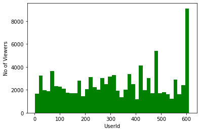

```python
plt.hist(x=movie_rating['userId'], bins=40,color ='g')
plt.xlabel('UserId')
plt.ylabel('No of Viewers')
plt.show()
```

```python
# Number of Users who rated at least one movie:
print("Number of Users who rated at least one move: ", movie_rating.userId.nunique())
print("-"*25)

# Number of Movies in the dataset:
print("Number of Movies in the dataset:", movie_rating.title.nunique())
print("-"*25)

# Unique of Rating points in the dataset:
print("Unique Rating points:", movie_rating.rating.unique())
```

```
Number of Users who rated at least one move:  610
-------------------------
Number of Movies in the dataset: 9719
-------------------------
Unique Rating points: [4.  4.5 2.5 3.5 3.  5.  0.5 2.  1.5 1. ]
```

# Extracting movie release years into one column

```python
movie_rating['movie_year'] = movie_rating.title.str.extract('.*\((.*)\).*')
movie_rating.head()
```

|  | movieId | title | genres | userId | rating | timestamp | movie_year |
| --- | --- | --- | --- | --- | --- | --- | --- |
| 0 | 1 | Toy Story (1995) | Adventure\|Animation\|Children\|Comedy\|Fantasy | 1 | 4.0 | 964982703 | 1995 |
| 1 | 1 | Toy Story (1995) | Adventure\|Animation\|Children\|Comedy\|Fantasy | 5 | 4.0 | 847434962 | 1995 |
| 2 | 1 | Toy Story (1995) | Adventure\|Animation\|Children\|Comedy\|Fantasy | 7 | 4.5 | 1106635946 | 1995 |
| 3 | 1 | Toy Story (1995) | Adventure\|Animation\|Children\|Comedy\|Fantasy | 15 | 2.5 | 1510577970 | 1995 |
| 4 | 1 | Toy Story (1995) | Adventure\|Animation\|Children\|Comedy\|Fantasy | 17 | 4.5 | 1305696483 | 1995 |

# grouping the movies based on average rating

```python
average_rating_movies = movie_rating.groupby('title')['rating'].mean().sort_values(ascending=False)
```

```python
average_rating_movies
```

```
title
Gena the Crocodile (1969)                  5.0
True Stories (1986)                        5.0
Cosmic Scrat-tastrophe (2015)              5.0
Love and Pigeons (1985)                    5.0
Red Sorghum (Hong gao liang) (1987)        5.0
                                          ...
Don't Look Now (1973)                      0.5
Journey 2: The Mysterious Island (2012)    0.5
Joe Dirt 2: Beautiful Loser (2015)         0.5
Jesus Christ Vampire Hunter (2001)         0.5
Fullmetal Alchemist 2018 (2017)            0.5
Name: rating, Length: 9719, dtype: float64
```

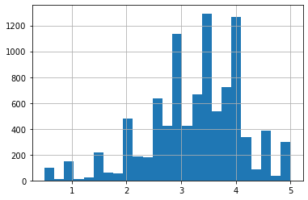

```python
average_rating_movies.hist(bins=25)
plt.show()
```

So from abive we could infer that the maximum movies have average rating in the range 3 to 4. The movies which have average = 5.0 may be the ones which may have been watched once or twice.

# Now we mgrouping the movies based on count of users who rated the movies

```python
count_userid = movie_rating.groupby('title')['userId'].count().sort_values(ascending=False)
```

```python
count_userid
```

```
title
Forrest Gump (1994)                          329
Shawshank Redemption, The (1994)             317
Pulp Fiction (1994)                          307
Silence of the Lambs, The (1991)             279
Matrix, The (1999)                           278
                                            ...
King Solomon's Mines (1950)                    1
King Solomon's Mines (1937)                    1
King Ralph (1991)                              1
King Kong Lives (1986)                         1
À nous la liberté (Freedom for Us) (1931)      1
Name: userId, Length: 9719, dtype: int64
```

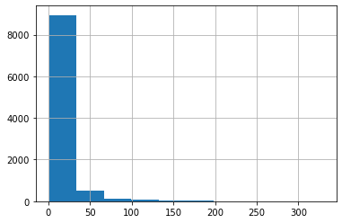

```python
count_userid.hist()
plt.show()
```

So from above we could infer that the maximum movies have been viewed in the range 0 - 40 views

The movies which have average = 5.0 may be the ones which may have been watched once or twice. Let's see number of ratings given to movies which have average rating = 5.0

```python
for movie in average_rating_movies[average_rating_movies==5.0].index:
    print(movie,count_userid[movie])
```

```
Gena the Crocodile (1969) 1
True Stories (1986) 1
Cosmic Scrat-tastrophe (2015) 1
Love and Pigeons (1985) 1
Red Sorghum (Hong gao liang) (1987) 1
Thin Line Between Love and Hate, A (1996) 1
Lesson Faust (1994) 2
Eva (2011) 1
Who Killed Chea Vichea? (2010) 1
Siam Sunset (1999) 1
Ex Drummer (2007) 1
Reform School Girls (1986) 1
Buzzard (2015) 1
Hellbenders (2012) 1
Heidi Fleiss: Hollywood Madam (1995) 2
My Left Eye Sees Ghosts (Ngo joh aan gin diy gwai) (2002) 1
Animals are Beautiful People (1974) 1
My Life as McDull (Mak dau goo si) (2001) 1
My Love (2006) 1
My Man Godfrey (1957) 1
Continental Divide (1981) 1
My Sassy Girl (Yeopgijeogin geunyeo) (2001) 1
Trinity and Sartana Are Coming (1972) 1
Calcium Kid, The (2004) 1
Connections (1978) 1
Superman/Batman: Public Enemies (2009) 1
Mystery of the Third Planet, The (Tayna tretey planety) (1981) 1
Mr. Skeffington (1944) 1
Shogun Assassin (1980) 1
Tickling Giants (2017) 1
Entertaining Angels: The Dorothy Day Story (1996) 1
Crippled Avengers (Can que) (Return of the 5 Deadly Venoms) (1981) 1
Tales of Manhattan (1942) 1
Monster Squad, The (1987) 1
SORI: Voice from the Heart (2016) 1
Awfully Big Adventure, An (1995) 1
Brother (Brat) (1997) 1
Light Years (Gandahar) (1988) 1
Moonlight 1
There Once Was a Dog (1982) 1
```

[output cut: 241 more lines]

```
L.A. Slasher (2015) 1
Palindromes (2004) 1
Goodbye Charlie (1964) 1
'Salem's Lot (2004) 1
Garfield's Pet Force (2009) 1
George Carlin: Back in Town (1996) 1
9/11 (2002) 1
Only Lovers Left Alive (2013) 1
Obsession (1965) 1
Oscar (1967) 1
Tom Segura: Completely Normal (2014) 1
George Carlin: It's Bad for Ya! (2008) 1
Garden of Words, The (Koto no ha no niwa) (2013) 1
Go for Zucker! (Alles auf Zucker!) (2004) 1
Open Hearts (Elsker dig for evigt) (2002) 1
```

# So we are grouping the movie_rating based on count on userId and mean on rating

```python
userid_rating = movie_rating.groupby('title')[['userId','rating']].agg({'userId':'count','rating':'mean'}).round(2).sort_values(by='userId',ascending=False)
```

```python
userid_rating.head(50)
```

| title | userId | rating |
| --- | --- | --- |
| Forrest Gump (1994) | 329 | 4.16 |
| Shawshank Redemption, The (1994) | 317 | 4.43 |
| Pulp Fiction (1994) | 307 | 4.20 |
| Silence of the Lambs, The (1991) | 279 | 4.16 |
| Matrix, The (1999) | 278 | 4.19 |
| Star Wars: Episode IV - A New Hope (1977) | 251 | 4.23 |
| Jurassic Park (1993) | 238 | 3.75 |
| Braveheart (1995) | 237 | 4.03 |
| Terminator 2: Judgment Day (1991) | 224 | 3.97 |
| Schindler's List (1993) | 220 | 4.22 |
| Fight Club (1999) | 218 | 4.27 |
| Toy Story (1995) | 215 | 3.92 |
| Star Wars: Episode V - The Empire Strikes Back (1980) | 211 | 4.22 |
| Usual Suspects, The (1995) | 204 | 4.24 |
| American Beauty (1999) | 204 | 4.06 |
| Seven (a.k.a. Se7en) (1995) | 203 | 3.98 |
| Independence Day (a.k.a. ID4) (1996) | 202 | 3.45 |
| Apollo 13 (1995) | 201 | 3.85 |
| Raiders of the Lost Ark (Indiana Jones and the Raiders of the Lost Ark) (1981) | 200 | 4.21 |
| Lord of the Rings: The Fellowship of the Ring, The (2001) | 198 | 4.11 |
| Star Wars: Episode VI - Return of the Jedi (1983) | 196 | 4.14 |
| Godfather, The (1972) | 192 | 4.29 |
| Fugitive, The (1993) | 190 | 3.99 |
| Batman (1989) | 189 | 3.43 |
| Saving Private Ryan (1998) | 188 | 4.15 |
| Lord of the Rings: The Two Towers, The (2002) | 188 | 4.02 |
| Lord of the Rings: The Return of the King, The (2003) | 185 | 4.12 |
| Aladdin (1992) | 183 | 3.79 |
| Fargo (1996) | 181 | 4.12 |
| Sixth Sense, The (1999) | 179 | 3.89 |
| True Lies (1994) | 178 | 3.50 |
| Twelve Monkeys (a.k.a. 12 Monkeys) (1995) | 177 | 3.98 |
| Lion King, The (1994) | 172 | 3.94 |
| Back to the Future (1985) | 171 | 4.04 |
| Speed (1994) | 171 | 3.53 |
| Shrek (2001) | 170 | 3.87 |
| Gladiator (2000) | 170 | 3.94 |
| Men in Black (a.k.a. MIB) (1997) | 165 | 3.49 |
| Dances with Wolves (1990) | 164 | 3.84 |
| Mission: Impossible (1996) | 162 | 3.54 |
| Ace Ventura: Pet Detective (1994) | 161 | 3.04 |
| Memento (2000) | 159 | 4.12 |
| Mask, The (1994) | 157 | 3.18 |
| Pirates of the Caribbean: The Curse of the Black Pearl (2003) | 149 | 3.78 |
| Dark Knight, The (2008) | 149 | 4.24 |
| Alien (1979) | 146 | 3.97 |
| Beauty and the Beast (1991) | 146 | 3.77 |
| Die Hard (1988) | 145 | 3.86 |
| Mrs. Doubtfire (1993) | 144 | 3.39 |
| Die Hard: With a Vengeance (1995) | 144 | 3.56 |

```python
userid_rating.tail(30)
```

| title | userId | rating |
| --- | --- | --- |
| Kill the Messenger (2014) | 1 | 3.0 |
| Kill List (2011) | 1 | 4.5 |
| Kiss Me Kate (1953) | 1 | 3.5 |
| Kidnapping, Caucasian Style (Kavkazskaya plennitsa) (1967) | 1 | 4.5 |
| Kidnapping Mr. Heineken (2015) | 1 | 2.0 |
| Kid's Story (2003) | 1 | 3.0 |
| Kicking Off (2016) | 1 | 1.5 |
| Kickin It Old Skool (2007) | 1 | 2.0 |
| Kickboxer (1989) | 1 | 2.5 |
| Keys to the House, The (Chiavi di casa, Le) (2004) | 1 | 3.0 |
| Killing Me Softly (2002) | 1 | 4.0 |
| Killshot (2008) | 1 | 2.5 |
| Kindergarten Cop 2 (2016) | 1 | 1.5 |
| Kindred, The (1986) | 1 | 1.0 |
| Kiss Me Goodbye (1982) | 1 | 3.5 |
| Kingsglaive: Final Fantasy XV (2016) | 1 | 3.5 |
| King's Ransom (2005) | 1 | 2.5 |
| King of Masks, The (Bian Lian) (1996) | 1 | 4.0 |
| King of Kings (1961) | 1 | 3.0 |
| King of Hearts (1966) | 1 | 5.0 |
| King of Comedy (Hei kek ji wong) (1999) | 1 | 4.0 |
| King of California (2007) | 1 | 3.0 |
| King in New York, A (1957) | 1 | 4.0 |
| King and I, The (1999) | 1 | 3.0 |
| King Solomon's Mines (1985) | 1 | 2.5 |
| King Solomon's Mines (1950) | 1 | 3.0 |
| King Solomon's Mines (1937) | 1 | 2.5 |
| King Ralph (1991) | 1 | 1.5 |
| King Kong Lives (1986) | 1 | 2.0 |
| À nous la liberté (Freedom for Us) (1931) | 1 | 1.0 |

# Now we are Building Recommendation System

creating pivot table to create item by item collaborative filtering

```python
movie_rating_pivot = pd.pivot_table(index='userId',columns='title',values='rating',data=movie_rating)
```

```python
movie_rating_pivot.head(10)
```

| title userId | '71 (2014) | 'Hellboy': The Seeds of Creation (2004) | 'Round Midnight (1986) | 'Salem's Lot (2004) | 'Til There Was You (1997) | 'Tis the Season for Love (2015) | 'burbs, The (1989) | 'night Mother (1986) | (500) Days of Summer (2009) | *batteries not included (1987) | ... | Zulu (2013) | [REC] (2007) | [REC]² (2009) | [REC]³ 3 Génesis (2012) | anohana: The Flower We Saw That Day - The Movie (2013) | eXistenZ (1999) | xXx (2002) | xXx: State of the Union (2005) | ¡Three Amigos! (1986) | À nous la liberté (Freedom for Us) (1931) |
| --- | --- | --- | --- | --- | --- | --- | --- | --- | --- | --- | --- | --- | --- | --- | --- | --- | --- | --- | --- | --- | --- |
| 1 | NaN | NaN | NaN | NaN | NaN | NaN | NaN | NaN | NaN | NaN | ... | NaN | NaN | NaN | NaN | NaN | NaN | NaN | NaN | 4.0 | NaN |
| 2 | NaN | NaN | NaN | NaN | NaN | NaN | NaN | NaN | NaN | NaN | ... | NaN | NaN | NaN | NaN | NaN | NaN | NaN | NaN | NaN | NaN |
| 3 | NaN | NaN | NaN | NaN | NaN | NaN | NaN | NaN | NaN | NaN | ... | NaN | NaN | NaN | NaN | NaN | NaN | NaN | NaN | NaN | NaN |
| 4 | NaN | NaN | NaN | NaN | NaN | NaN | NaN | NaN | NaN | NaN | ... | NaN | NaN | NaN | NaN | NaN | NaN | NaN | NaN | NaN | NaN |
| 5 | NaN | NaN | NaN | NaN | NaN | NaN | NaN | NaN | NaN | NaN | ... | NaN | NaN | NaN | NaN | NaN | NaN | NaN | NaN | NaN | NaN |
| 6 | NaN | NaN | NaN | NaN | NaN | NaN | NaN | NaN | NaN | NaN | ... | NaN | NaN | NaN | NaN | NaN | NaN | NaN | NaN | NaN | NaN |
| 7 | NaN | NaN | NaN | NaN | NaN | NaN | NaN | NaN | NaN | NaN | ... | NaN | NaN | NaN | NaN | NaN | NaN | NaN | NaN | NaN | NaN |
| 8 | NaN | NaN | NaN | NaN | NaN | NaN | NaN | NaN | NaN | NaN | ... | NaN | NaN | NaN | NaN | NaN | NaN | NaN | NaN | NaN | NaN |
| 9 | NaN | NaN | NaN | NaN | NaN | NaN | NaN | NaN | NaN | NaN | ... | NaN | NaN | NaN | NaN | NaN | NaN | 1.0 | NaN | NaN | NaN |
| 10 | NaN | NaN | NaN | NaN | NaN | NaN | NaN | NaN | NaN | NaN | ... | NaN | NaN | NaN | NaN | NaN | NaN | NaN | NaN | NaN | NaN |

10 rows × 9719 columns

there are so many NAN values in above movie_rating be many Nan values because users have watched only few of the movies and given ratings only to those movies

# Mostly rated movies below

```python
userid_rating.head(10)
```

| title | userId | rating |
| --- | --- | --- |
| Forrest Gump (1994) | 329 | 4.16 |
| Shawshank Redemption, The (1994) | 317 | 4.43 |
| Pulp Fiction (1994) | 307 | 4.20 |
| Silence of the Lambs, The (1991) | 279 | 4.16 |
| Matrix, The (1999) | 278 | 4.19 |
| Star Wars: Episode IV - A New Hope (1977) | 251 | 4.23 |
| Jurassic Park (1993) | 238 | 3.75 |
| Braveheart (1995) | 237 | 4.03 |
| Terminator 2: Judgment Day (1991) | 224 | 3.97 |
| Schindler's List (1993) | 220 | 4.22 |

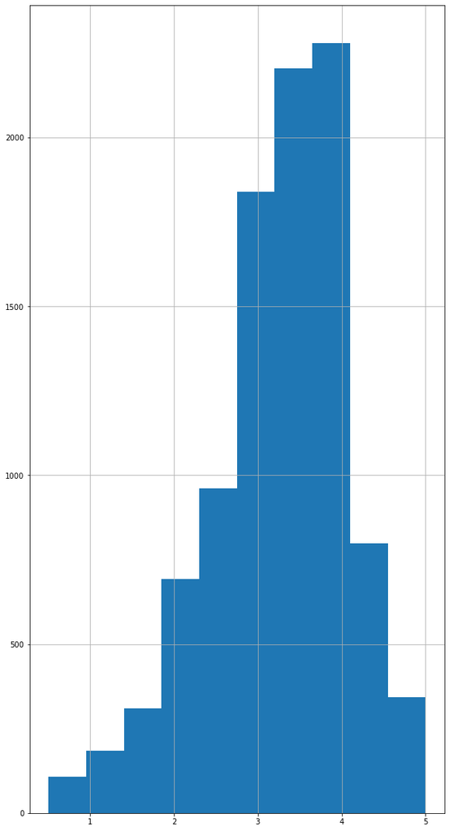

```python
userid_rating['rating'].hist(figsize= (10,20))
plt.show()
```

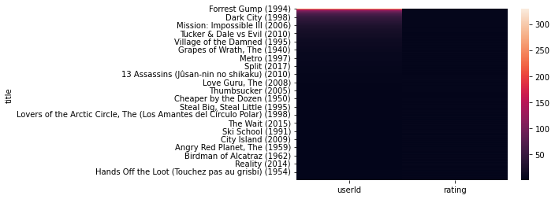

```python
sns.heatmap(userid_rating)
plt.show()
```

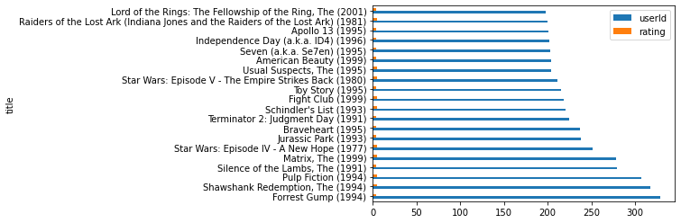

```python
userid_rating.head(20).plot(kind="barh")
```

So from above we could say clearly about the movies that customers want to watch, as demonstrated by their post-viewing ratings

# Now we find out the correlation to find out the list of movie recommendations, which contains at least one that the user will start watching as their next selection.

So now we find which movies to recommend to the users who have watched 'Toy Story (1995)'[we have taken Toy Story as the refrence movie for recomender system model). To do this we have to find correlation of 'Toay (1995)' with other movies which have been rated in a similar way by the users.

# assigning ratings of movie 'Toy (1995)' to a new variable from movie_rating_pivot

```python
Toy_Story = movie_rating_pivot['Toy Story (1995)'].head(10)
```

```python
Toy_Story.head(20)
```

```
userId
1     4.0
2     NaN
3     NaN
4     NaN
5     4.0
6     NaN
7     4.5
8     NaN
9     NaN
10    NaN
Name: Toy Story (1995), dtype: float64
```

Now we have to find the the correlation with other movie from movie_rating_pivot

```python
corr_Toy_Story = pd.DataFrame(movie_rating_pivot.corrwith(Toy_Story))
```

```python
corr_Toy_Story.head(50)
```

| title | 0 |
| --- | --- |
| '71 (2014) | NaN |
| 'Hellboy': The Seeds of Creation (2004) | NaN |
| 'Round Midnight (1986) | NaN |
| 'Salem's Lot (2004) | NaN |
| 'Til There Was You (1997) | NaN |
| 'Tis the Season for Love (2015) | NaN |
| 'burbs, The (1989) | NaN |
| 'night Mother (1986) | NaN |
| (500) Days of Summer (2009) | NaN |
| *batteries not included (1987) | NaN |
| ...All the Marbles (1981) | NaN |
| ...And Justice for All (1979) | NaN |
| 00 Schneider - Jagd auf Nihil Baxter (1994) | NaN |
| 1-900 (06) (1994) | NaN |
| 10 (1979) | NaN |
| 10 Cent Pistol (2015) | NaN |
| 10 Cloverfield Lane (2016) | NaN |
| 10 Items or Less (2006) | NaN |
| 10 Things I Hate About You (1999) | NaN |
| 10 Years (2011) | NaN |
| 10,000 BC (2008) | NaN |
| 100 Girls (2000) | NaN |
| 100 Streets (2016) | NaN |
| 101 Dalmatians (1996) | NaN |
| 101 Dalmatians (One Hundred and One Dalmatians) (1961) | NaN |
| 101 Dalmatians II: Patch's London Adventure (2003) | NaN |
| 101 Reykjavik (101 Reykjavík) (2000) | NaN |
| 102 Dalmatians (2000) | NaN |
| 10th & Wolf (2006) | NaN |
| 10th Kingdom, The (2000) | NaN |
| 10th Victim, The (La decima vittima) (1965) | NaN |
| 11'09"01 - September 11 (2002) | NaN |
| 11:14 (2003) | NaN |
| 11th Hour, The (2007) | NaN |
| 12 Angry Men (1957) | NaN |
| 12 Angry Men (1997) | NaN |
| 12 Chairs (1971) | NaN |
| 12 Chairs (1976) | NaN |
| 12 Rounds (2009) | NaN |
| 12 Years a Slave (2013) | NaN |
| 127 Hours (2010) | NaN |
| 13 Assassins (Jûsan-nin no shikaku) (2010) | NaN |
| 13 Ghosts (1960) | NaN |
| 13 Going on 30 (2004) | NaN |
| 13 Hours (2016) | NaN |
| 13 Sins (2014) | NaN |
| 13 Tzameti (2005) | NaN |
| 13th (2016) | NaN |
| 13th Warrior, The (1999) | NaN |
| 1408 (2007) | NaN |

# Now we have to remove NAN value from above

```python
corr_Toy_Story.columns = ['Correlation']
corr_Toy_Story.dropna(inplace=True,axis=0)
```

```python
corr_Toy_Story.sort_values(by='Correlation',ascending=True).head(20)
```

| title | Correlation |
| --- | --- |
| X-Men (2000) | -1.0 |
| Austin Powers: International Man of Mystery (1997) | -1.0 |
| Beauty and the Beast (1991) | -1.0 |
| Enemy of the State (1998) | -1.0 |
| Gladiator (2000) | -1.0 |
| Terminator 2: Judgment Day (1991) | -1.0 |
| Superman (1978) | -1.0 |
| Star Wars: Episode VI - Return of the Jedi (1983) | -1.0 |
| Star Wars: Episode V - The Empire Strikes Back (1980) | -1.0 |
| Star Wars: Episode I - The Phantom Menace (1999) | -1.0 |
| Rocky (1976) | -1.0 |
| Postman, The (Postino, Il) (1994) | -1.0 |
| Aladdin (1992) | -1.0 |
| Blues Brothers, The (1980) | -1.0 |
| American Beauty (1999) | -1.0 |
| L.A. Confidential (1997) | -1.0 |
| Batman (1989) | -0.5 |
| Usual Suspects, The (1995) | 0.0 |
| Jurassic Park (1993) | 1.0 |
| Silence of the Lambs, The (1991) | 1.0 |

So from above we could say that there may be movies which might have been watched only once or twice by the users who have watched 'Toy Story (1995)' and those movies will show high correlation. We will consider only those movies which have been viewed more than 100 times. Let's add views column in the correlation_Toy_Story data frame.

```python
corr_Toy_Story.sort_values(by='Correlation',ascending=True).head(20)
```

| title | Correlation |
| --- | --- |
| X-Men (2000) | -1.0 |
| Austin Powers: International Man of Mystery (1997) | -1.0 |
| Beauty and the Beast (1991) | -1.0 |
| Enemy of the State (1998) | -1.0 |
| Gladiator (2000) | -1.0 |
| Terminator 2: Judgment Day (1991) | -1.0 |
| Superman (1978) | -1.0 |
| Star Wars: Episode VI - Return of the Jedi (1983) | -1.0 |
| Star Wars: Episode V - The Empire Strikes Back (1980) | -1.0 |
| Star Wars: Episode I - The Phantom Menace (1999) | -1.0 |
| Rocky (1976) | -1.0 |
| Postman, The (Postino, Il) (1994) | -1.0 |
| Aladdin (1992) | -1.0 |
| Blues Brothers, The (1980) | -1.0 |
| American Beauty (1999) | -1.0 |
| L.A. Confidential (1997) | -1.0 |
| Batman (1989) | -0.5 |
| Usual Suspects, The (1995) | 0.0 |
| Jurassic Park (1993) | 1.0 |
| Silence of the Lambs, The (1991) | 1.0 |

```python
corr_Toy_Story['Views'] = userid_rating['userId']
```

```python
corr_Toy_Story['Views']
```

```
title
Aladdin (1992)                                           183
American Beauty (1999)                                   204
Apollo 13 (1995)                                         201
Austin Powers: International Man of Mystery (1997)       100
Batman (1989)                                            189
Beauty and the Beast (1991)                              146
Blues Brothers, The (1980)                                84
Enemy of the State (1998)                                 67
Forrest Gump (1994)                                      329
Gladiator (2000)                                         170
Independence Day (a.k.a. ID4) (1996)                     202
Jurassic Park (1993)                                     238
L.A. Confidential (1997)                                  97
Mission: Impossible (1996)                               162
Postman, The (Postino, Il) (1994)                         37
Psycho (1960)                                             83
Rocky (1976)                                              64
Silence of the Lambs, The (1991)                         279
Star Wars: Episode I - The Phantom Menace (1999)         140
Star Wars: Episode V - The Empire Strikes Back (1980)    211
Star Wars: Episode VI - Return of the Jedi (1983)        196
Superman (1978)                                           61
Terminator 2: Judgment Day (1991)                        224
Toy Story (1995)                                         215
True Lies (1994)                                         178
Usual Suspects, The (1995)                               204
X-Men (2000)                                             133
Name: Views, dtype: int64
```

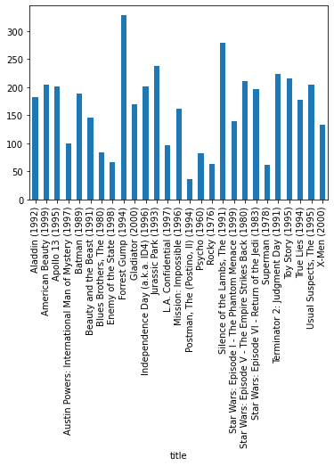

```python
corr_Toy_Story['Views'].plot(kind='bar')
```

# Now we have to filtering out top 25 movies which have views greater than 100

```python
corr_df= corr_Toy_Story[corr_Toy_Story['Views'] > 100].sort_values(by='Correlation',ascending=False).head(25)
```

```python
corr_df
```

| title | Correlation | Views |
| --- | --- | --- |
| Apollo 13 (1995) | 1.0 | 201 |
| Independence Day (a.k.a. ID4) (1996) | 1.0 | 202 |
| Toy Story (1995) | 1.0 | 215 |
| Mission: Impossible (1996) | 1.0 | 162 |
| Forrest Gump (1994) | 1.0 | 329 |
| True Lies (1994) | 1.0 | 178 |
| Jurassic Park (1993) | 1.0 | 238 |
| Silence of the Lambs, The (1991) | 1.0 | 279 |
| Usual Suspects, The (1995) | 0.0 | 204 |
| Batman (1989) | -0.5 | 189 |
| Star Wars: Episode VI - Return of the Jedi (1983) | -1.0 | 196 |
| Terminator 2: Judgment Day (1991) | -1.0 | 224 |
| Aladdin (1992) | -1.0 | 183 |
| Star Wars: Episode V - The Empire Strikes Back (1980) | -1.0 | 211 |
| Star Wars: Episode I - The Phantom Menace (1999) | -1.0 | 140 |
| American Beauty (1999) | -1.0 | 204 |
| Gladiator (2000) | -1.0 | 170 |
| Beauty and the Beast (1991) | -1.0 | 146 |
| X-Men (2000) | -1.0 | 133 |

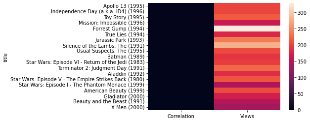

```python
sns.heatmap(corr_df)
plt.show()
```

So above movie name is the list of movie recommendations, which contains at least one that the user will start watching as their next selection.

```python
movieId_dict = movie_rating.drop_duplicates('title')[['movieId', 'title']].set_index('movieId').to_dict()['title']

# First 5 elements of this dictionary

list(movieId_dict.items())[:5]
```

```
[(1, 'Toy Story (1995)'),
 (2, 'Jumanji (1995)'),
 (3, 'Grumpier Old Men (1995)'),
 (4, 'Waiting to Exhale (1995)'),
 (5, 'Father of the Bride Part II (1995)')]
```

```python
genres1=movie_rating['genres'].unique()
```

```python
genres1
```

```
array(['Adventure|Animation|Children|Comedy|Fantasy',
       'Adventure|Children|Fantasy', 'Comedy|Romance',
       'Comedy|Drama|Romance', 'Comedy', 'Action|Crime|Thriller',
       'Adventure|Children', 'Action', 'Action|Adventure|Thriller',
       'Comedy|Horror', 'Adventure|Animation|Children', 'Drama',
       'Action|Adventure|Romance', 'Crime|Drama', 'Drama|Romance',
       'Action|Comedy|Crime|Drama|Thriller', 'Comedy|Crime|Thriller',
       'Crime|Drama|Horror|Mystery|Thriller', 'Drama|Sci-Fi',
       'Children|Drama', 'Adventure|Drama|Fantasy|Mystery|Sci-Fi',
       'Mystery|Sci-Fi|Thriller', 'Children|Comedy', 'Drama|War',
       'Action|Crime|Drama', 'Action|Adventure|Fantasy',
       'Comedy|Drama|Thriller', 'Mystery|Thriller',
       'Animation|Children|Drama|Musical|Romance',
       'Crime|Mystery|Thriller', 'Adventure|Drama', 'Drama|Thriller',
       'Comedy|Crime', 'Action|Sci-Fi|Thriller',
       'Action|Comedy|Horror|Thriller', 'Comedy|Drama', 'Documentary',
       'Action|Crime|Drama|Thriller', 'Crime|Drama|Romance',
       'Action|Adventure|Drama', 'Action|Thriller',
       'Drama|Horror|Thriller', 'Comedy|Horror|Romance',
       'Adventure|Comedy|Crime|Romance',
       'Adventure|Children|Comedy|Musical', 'Action|Drama|War',
       'Crime|Drama|Thriller', 'Action|Adventure|Comedy|Crime',
       'Drama|Mystery', 'Drama|Mystery|Romance', 'Thriller',
       'Adventure|Drama|IMAX', 'Action|Drama|Romance|War', 'Drama|Horror',
       'Adventure|Drama|War', 'Comedy|War', 'Crime|Drama|Mystery',
       'Action|Adventure|Mystery|Sci-Fi', 'Drama|Thriller|War',
       'Action|Romance|Western', 'Crime|Film-Noir|Mystery|Thriller',
       'Comedy|Crime|Drama', 'Action|Drama|Romance',
       'Adventure|Children|Drama', 'Action|Adventure|Crime|Thriller',
       'Action|Crime|Sci-Fi', 'Horror', 'Action|Children',
       'Comedy|Horror|Thriller', 'Fantasy|Horror|Mystery',
       'Comedy|Fantasy', 'Horror|Sci-Fi',
       'Action|Crime|Drama|Mystery|Sci-Fi|Thriller',
       'Drama|Musical|Romance', 'Drama|Fantasy',
       'Action|Adventure|Sci-Fi', 'Western',
       'Adventure|Comedy|Crime|Mystery', 'Adventure|Comedy',
       'Action|Comedy|Romance', 'Animation|Children|Comedy|Romance',
       'Drama|Musical', 'Children|Comedy|Fantasy', 'Comedy|Sci-Fi',
       'Adventure|Children|Comedy|Fantasy|Romance',
       'Drama|Fantasy|Romance', 'Drama|Romance|War|Western',
```

[output cut: 543 more lines]

```
       'Adventure|Children|Drama|Sci-Fi',
       'Adventure|Children|Comedy|Drama|Fantasy|Sci-Fi',
       'Animation|Fantasy|Horror|Mystery',
       'Adventure|Animation|Fantasy|Horror|Sci-Fi',
       'Action|Animation|Crime|Drama',
       'Action|Adventure|Animation|Drama|Fantasy|Sci-Fi',
       'Action|Animation|Mystery', 'Animation|Drama|Sci-Fi',
       'Animation|Drama|Fantasy|Romance',
       'Action|Adventure|Comedy|Fantasy|Sci-Fi|Thriller',
       'Action|Adventure|Fantasy|Horror|Thriller', 'Comedy|Sci-Fi|War',
       'Comedy|Mystery|Romance|Thriller', 'Fantasy|Horror|Sci-Fi|Western',
       'Animation|Crime|Drama', 'Adventure|Mystery|Sci-Fi|Thriller',
       'Action|Comedy|Crime|Horror', 'Action|Adventure|Children|Sci-Fi',
       'Action|Adventure|Comedy|Fantasy|Sci-Fi',
       'Action|Animation|Comedy|Fantasy'], dtype=object)
```

```python
genres1.shape
```

```
(951,)
```

```python
genres2= movie_rating['genres'].str.split('|')
genres2
```

```
0         [Adventure, Animation, Children, Comedy, Fantasy]
1         [Adventure, Animation, Children, Comedy, Fantasy]
2         [Adventure, Animation, Children, Comedy, Fantasy]
3         [Adventure, Animation, Children, Comedy, Fantasy]
4         [Adventure, Animation, Children, Comedy, Fantasy]
                                ...
100831                 [Action, Animation, Comedy, Fantasy]
100832                         [Animation, Comedy, Fantasy]
100833                                              [Drama]
100834                                  [Action, Animation]
100835                                             [Comedy]
Name: genres, Length: 100836, dtype: object
```

```python
genres_unique=set()
for u in genres2:
    genres_unique=genres_unique.union(set(u))
```

```python
genres_unique
```

```
{'(no genres listed)',
 'Action',
 'Adventure',
 'Animation',
 'Children',
 'Comedy',
 'Crime',
 'Documentary',
 'Drama',
 'Fantasy',
 'Film-Noir',
 'Horror',
 'IMAX',
 'Musical',
 'Mystery',
 'Romance',
 'Sci-Fi',
 'Thriller',
 'War',
 'Western'}
```

```python
len(genres_unique)
```

```
20
```

# 20 gneres listed present in movie_rating data

```python
from sklearn.preprocessing import OneHotEncoder
```

```python
movie_rating_genres= movie_rating['genres'].str.get_dummies('|')
movie_rating_genres
```

|  | (no genres listed) | Action | Adventure | Animation | Children | Comedy | Crime | Documentary | Drama | Fantasy | Film-Noir | Horror | IMAX | Musical | Mystery | Romance | Sci-Fi | Thriller | War | Western |
| --- | --- | --- | --- | --- | --- | --- | --- | --- | --- | --- | --- | --- | --- | --- | --- | --- | --- | --- | --- | --- |
| 0 | 0 | 0 | 1 | 1 | 1 | 1 | 0 | 0 | 0 | 1 | 0 | 0 | 0 | 0 | 0 | 0 | 0 | 0 | 0 | 0 |
| 1 | 0 | 0 | 1 | 1 | 1 | 1 | 0 | 0 | 0 | 1 | 0 | 0 | 0 | 0 | 0 | 0 | 0 | 0 | 0 | 0 |
| 2 | 0 | 0 | 1 | 1 | 1 | 1 | 0 | 0 | 0 | 1 | 0 | 0 | 0 | 0 | 0 | 0 | 0 | 0 | 0 | 0 |
| 3 | 0 | 0 | 1 | 1 | 1 | 1 | 0 | 0 | 0 | 1 | 0 | 0 | 0 | 0 | 0 | 0 | 0 | 0 | 0 | 0 |
| 4 | 0 | 0 | 1 | 1 | 1 | 1 | 0 | 0 | 0 | 1 | 0 | 0 | 0 | 0 | 0 | 0 | 0 | 0 | 0 | 0 |
| ... | ... | ... | ... | ... | ... | ... | ... | ... | ... | ... | ... | ... | ... | ... | ... | ... | ... | ... | ... | ... |
| 100831 | 0 | 1 | 0 | 1 | 0 | 1 | 0 | 0 | 0 | 1 | 0 | 0 | 0 | 0 | 0 | 0 | 0 | 0 | 0 | 0 |
| 100832 | 0 | 0 | 0 | 1 | 0 | 1 | 0 | 0 | 0 | 1 | 0 | 0 | 0 | 0 | 0 | 0 | 0 | 0 | 0 | 0 |
| 100833 | 0 | 0 | 0 | 0 | 0 | 0 | 0 | 0 | 1 | 0 | 0 | 0 | 0 | 0 | 0 | 0 | 0 | 0 | 0 | 0 |
| 100834 | 0 | 1 | 0 | 1 | 0 | 0 | 0 | 0 | 0 | 0 | 0 | 0 | 0 | 0 | 0 | 0 | 0 | 0 | 0 | 0 |
| 100835 | 0 | 0 | 0 | 0 | 0 | 1 | 0 | 0 | 0 | 0 | 0 | 0 | 0 | 0 | 0 | 0 | 0 | 0 | 0 | 0 |

100836 rows × 20 columns

```python
final_data=pd.merge(movie_rating,movie_rating_genres, how='inner', left_index=True, right_index=True)
```

```python
final_data.head(20)
```

|  | movieId | title | genres | userId | rating | timestamp | movie_year | (no genres listed) | Action | Adventure | ... | Film-Noir | Horror | IMAX | Musical | Mystery | Romance | Sci-Fi | Thriller | War | Western |
| --- | --- | --- | --- | --- | --- | --- | --- | --- | --- | --- | --- | --- | --- | --- | --- | --- | --- | --- | --- | --- | --- |
| 0 | 1 | Toy Story (1995) | Adventure\|Animation\|Children\|Comedy\|Fantasy | 1 | 4.0 | 964982703 | 1995 | 0 | 0 | 1 | ... | 0 | 0 | 0 | 0 | 0 | 0 | 0 | 0 | 0 | 0 |
| 1 | 1 | Toy Story (1995) | Adventure\|Animation\|Children\|Comedy\|Fantasy | 5 | 4.0 | 847434962 | 1995 | 0 | 0 | 1 | ... | 0 | 0 | 0 | 0 | 0 | 0 | 0 | 0 | 0 | 0 |
| 2 | 1 | Toy Story (1995) | Adventure\|Animation\|Children\|Comedy\|Fantasy | 7 | 4.5 | 1106635946 | 1995 | 0 | 0 | 1 | ... | 0 | 0 | 0 | 0 | 0 | 0 | 0 | 0 | 0 | 0 |
| 3 | 1 | Toy Story (1995) | Adventure\|Animation\|Children\|Comedy\|Fantasy | 15 | 2.5 | 1510577970 | 1995 | 0 | 0 | 1 | ... | 0 | 0 | 0 | 0 | 0 | 0 | 0 | 0 | 0 | 0 |
| 4 | 1 | Toy Story (1995) | Adventure\|Animation\|Children\|Comedy\|Fantasy | 17 | 4.5 | 1305696483 | 1995 | 0 | 0 | 1 | ... | 0 | 0 | 0 | 0 | 0 | 0 | 0 | 0 | 0 | 0 |
| 5 | 1 | Toy Story (1995) | Adventure\|Animation\|Children\|Comedy\|Fantasy | 18 | 3.5 | 1455209816 | 1995 | 0 | 0 | 1 | ... | 0 | 0 | 0 | 0 | 0 | 0 | 0 | 0 | 0 | 0 |
| 6 | 1 | Toy Story (1995) | Adventure\|Animation\|Children\|Comedy\|Fantasy | 19 | 4.0 | 965705637 | 1995 | 0 | 0 | 1 | ... | 0 | 0 | 0 | 0 | 0 | 0 | 0 | 0 | 0 | 0 |
| 7 | 1 | Toy Story (1995) | Adventure\|Animation\|Children\|Comedy\|Fantasy | 21 | 3.5 | 1407618878 | 1995 | 0 | 0 | 1 | ... | 0 | 0 | 0 | 0 | 0 | 0 | 0 | 0 | 0 | 0 |
| 8 | 1 | Toy Story (1995) | Adventure\|Animation\|Children\|Comedy\|Fantasy | 27 | 3.0 | 962685262 | 1995 | 0 | 0 | 1 | ... | 0 | 0 | 0 | 0 | 0 | 0 | 0 | 0 | 0 | 0 |
| 9 | 1 | Toy Story (1995) | Adventure\|Animation\|Children\|Comedy\|Fantasy | 31 | 5.0 | 850466616 | 1995 | 0 | 0 | 1 | ... | 0 | 0 | 0 | 0 | 0 | 0 | 0 | 0 | 0 | 0 |
| 10 | 1 | Toy Story (1995) | Adventure\|Animation\|Children\|Comedy\|Fantasy | 32 | 3.0 | 856736119 | 1995 | 0 | 0 | 1 | ... | 0 | 0 | 0 | 0 | 0 | 0 | 0 | 0 | 0 | 0 |
| 11 | 1 | Toy Story (1995) | Adventure\|Animation\|Children\|Comedy\|Fantasy | 33 | 3.0 | 939647444 | 1995 | 0 | 0 | 1 | ... | 0 | 0 | 0 | 0 | 0 | 0 | 0 | 0 | 0 | 0 |
| 12 | 1 | Toy Story (1995) | Adventure\|Animation\|Children\|Comedy\|Fantasy | 40 | 5.0 | 832058959 | 1995 | 0 | 0 | 1 | ... | 0 | 0 | 0 | 0 | 0 | 0 | 0 | 0 | 0 | 0 |
| 13 | 1 | Toy Story (1995) | Adventure\|Animation\|Children\|Comedy\|Fantasy | 43 | 5.0 | 848993983 | 1995 | 0 | 0 | 1 | ... | 0 | 0 | 0 | 0 | 0 | 0 | 0 | 0 | 0 | 0 |
| 14 | 1 | Toy Story (1995) | Adventure\|Animation\|Children\|Comedy\|Fantasy | 44 | 3.0 | 869251860 | 1995 | 0 | 0 | 1 | ... | 0 | 0 | 0 | 0 | 0 | 0 | 0 | 0 | 0 | 0 |
| 15 | 1 | Toy Story (1995) | Adventure\|Animation\|Children\|Comedy\|Fantasy | 45 | 4.0 | 951170182 | 1995 | 0 | 0 | 1 | ... | 0 | 0 | 0 | 0 | 0 | 0 | 0 | 0 | 0 | 0 |
| 16 | 1 | Toy Story (1995) | Adventure\|Animation\|Children\|Comedy\|Fantasy | 46 | 5.0 | 834787906 | 1995 | 0 | 0 | 1 | ... | 0 | 0 | 0 | 0 | 0 | 0 | 0 | 0 | 0 | 0 |
| 17 | 1 | Toy Story (1995) | Adventure\|Animation\|Children\|Comedy\|Fantasy | 50 | 3.0 | 1514238116 | 1995 | 0 | 0 | 1 | ... | 0 | 0 | 0 | 0 | 0 | 0 | 0 | 0 | 0 | 0 |
| 18 | 1 | Toy Story (1995) | Adventure\|Animation\|Children\|Comedy\|Fantasy | 54 | 3.0 | 830247330 | 1995 | 0 | 0 | 1 | ... | 0 | 0 | 0 | 0 | 0 | 0 | 0 | 0 | 0 | 0 |
| 19 | 1 | Toy Story (1995) | Adventure\|Animation\|Children\|Comedy\|Fantasy | 57 | 5.0 | 965796031 | 1995 | 0 | 0 | 1 | ... | 0 | 0 | 0 | 0 | 0 | 0 | 0 | 0 | 0 | 0 |

20 rows × 27 columns

```python
final_data['title'].head(5)
```

```
0    Toy Story (1995)
1    Toy Story (1995)
2    Toy Story (1995)
3    Toy Story (1995)
4    Toy Story (1995)
Name: title, dtype: object
```

```python
#Import TfIdfVectorizer from scikit-learn
from sklearn.feature_extraction.text import TfidfVectorizer

#Define a TF-IDF Vectorizer Object. Remove all english stop words such as 'the', 'a'
tfidf = TfidfVectorizer(stop_words='english')

#Replace NaN with an empty string
final_data['title'] = final_data['title'].fillna('')

#Construct the required TF-IDF matrix by fitting and transforming the data
tfidf_matrix = tfidf.fit_transform(final_data['title'])

#Output the shape of tfidf_matrix
tfidf_matrix.shape
```

```
(100836, 9037)
```

```python
ratings =pd.DataFrame(final_data.groupby('title')['rating'].mean())
```

```python
ratings.head(20)
```

| title | rating |
| --- | --- |
| '71 (2014) | 4.000000 |
| 'Hellboy': The Seeds of Creation (2004) | 4.000000 |
| 'Round Midnight (1986) | 3.500000 |
| 'Salem's Lot (2004) | 5.000000 |
| 'Til There Was You (1997) | 4.000000 |
| 'Tis the Season for Love (2015) | 1.500000 |
| 'burbs, The (1989) | 3.176471 |
| 'night Mother (1986) | 3.000000 |
| (500) Days of Summer (2009) | 3.666667 |
| *batteries not included (1987) | 3.285714 |
| ...All the Marbles (1981) | 2.000000 |
| ...And Justice for All (1979) | 3.166667 |
| 00 Schneider - Jagd auf Nihil Baxter (1994) | 4.500000 |
| 1-900 (06) (1994) | 4.000000 |
| 10 (1979) | 3.375000 |
| 10 Cent Pistol (2015) | 1.250000 |
| 10 Cloverfield Lane (2016) | 3.678571 |
| 10 Items or Less (2006) | 2.666667 |
| 10 Things I Hate About You (1999) | 3.527778 |
| 10 Years (2011) | 3.500000 |

```python
ratings['rating_numbers'] = pd.DataFrame(final_data.groupby('title')['rating'].count())
```

```python
ratings['rating_numbers']
```

```
title
'71 (2014)                                    1
'Hellboy': The Seeds of Creation (2004)       1
'Round Midnight (1986)                        2
'Salem's Lot (2004)                           1
'Til There Was You (1997)                     2
                                             ..
eXistenZ (1999)                              22
xXx (2002)                                   24
xXx: State of the Union (2005)                5
¡Three Amigos! (1986)                        26
À nous la liberté (Freedom for Us) (1931)     1
Name: rating_numbers, Length: 9719, dtype: int64
```

```python
ratings.head()
```

| title | rating | rating_numbers |
| --- | --- | --- |
| '71 (2014) | 4.0 | 1 |
| 'Hellboy': The Seeds of Creation (2004) | 4.0 | 1 |
| 'Round Midnight (1986) | 3.5 | 2 |
| 'Salem's Lot (2004) | 5.0 | 1 |
| 'Til There Was You (1997) | 4.0 | 2 |

# Create Pivot table

```python
movieRate = final_data.pivot_table(index='userId', columns='title', values='rating')
movieRate.fillna(0, inplace=True)
```

```python
movieRate.head()
```

| title userId | '71 (2014) | 'Hellboy': The Seeds of Creation (2004) | 'Round Midnight (1986) | 'Salem's Lot (2004) | 'Til There Was You (1997) | 'Tis the Season for Love (2015) | 'burbs, The (1989) | 'night Mother (1986) | (500) Days of Summer (2009) | *batteries not included (1987) | ... | Zulu (2013) | [REC] (2007) | [REC]² (2009) | [REC]³ 3 Génesis (2012) | anohana: The Flower We Saw That Day - The Movie (2013) | eXistenZ (1999) | xXx (2002) | xXx: State of the Union (2005) | ¡Three Amigos! (1986) | À nous la liberté (Freedom for Us) (1931) |
| --- | --- | --- | --- | --- | --- | --- | --- | --- | --- | --- | --- | --- | --- | --- | --- | --- | --- | --- | --- | --- | --- |
| 1 | 0.0 | 0.0 | 0.0 | 0.0 | 0.0 | 0.0 | 0.0 | 0.0 | 0.0 | 0.0 | ... | 0.0 | 0.0 | 0.0 | 0.0 | 0.0 | 0.0 | 0.0 | 0.0 | 4.0 | 0.0 |
| 2 | 0.0 | 0.0 | 0.0 | 0.0 | 0.0 | 0.0 | 0.0 | 0.0 | 0.0 | 0.0 | ... | 0.0 | 0.0 | 0.0 | 0.0 | 0.0 | 0.0 | 0.0 | 0.0 | 0.0 | 0.0 |
| 3 | 0.0 | 0.0 | 0.0 | 0.0 | 0.0 | 0.0 | 0.0 | 0.0 | 0.0 | 0.0 | ... | 0.0 | 0.0 | 0.0 | 0.0 | 0.0 | 0.0 | 0.0 | 0.0 | 0.0 | 0.0 |
| 4 | 0.0 | 0.0 | 0.0 | 0.0 | 0.0 | 0.0 | 0.0 | 0.0 | 0.0 | 0.0 | ... | 0.0 | 0.0 | 0.0 | 0.0 | 0.0 | 0.0 | 0.0 | 0.0 | 0.0 | 0.0 |
| 5 | 0.0 | 0.0 | 0.0 | 0.0 | 0.0 | 0.0 | 0.0 | 0.0 | 0.0 | 0.0 | ... | 0.0 | 0.0 | 0.0 | 0.0 | 0.0 | 0.0 | 0.0 | 0.0 | 0.0 | 0.0 |

5 rows × 9719 columns

# Recommendation system

```python
def recommendMovies(name , min_rating_count = 50):
    user_rating = movieRate[name]
    similar_movies = movieRate.corrwith(user_rating)
    corr_movies = pd.DataFrame(similar_movies, columns=['Correlation'])
    corr_movies.dropna(inplace=True)
    #corr_movies.sort_values('Correlation', ascending=False).head(10)
    # Joining the rating_number list so that we can filter basis minimum count of ratings to be considered
    # for recommending a movie
    corr_movies = corr_movies.join(ratings['rating_numbers'], how='left', lsuffix='_left', rsuffix='_right')

    final = corr_movies[corr_movies['rating_numbers']>min_rating_count].sort_values('Correlation', ascending=False)
    return final
```

```python
recommendations = recommendMovies('Year of the Horse (1997)')
recommendations.head(n=10)
```

| title | Correlation | rating_numbers |
| --- | --- | --- |
| Congo (1995) | 0.214585 | 57 |
| Miss Congeniality (2000) | 0.191742 | 64 |
| Dragonheart (1996) | 0.190548 | 65 |
| Eraser (1996) | 0.187618 | 64 |
| Three Musketeers, The (1993) | 0.186719 | 61 |
| Casper (1995) | 0.185991 | 62 |
| Notting Hill (1999) | 0.181281 | 56 |
| Bruce Almighty (2003) | 0.170231 | 71 |
| Air Force One (1997) | 0.168525 | 58 |
| Demolition Man (1993) | 0.167618 | 81 |

```python
recommendations = recommendMovies('Air Force One (1997)')
recommendations.head(n=10)
```

| title | Correlation | rating_numbers |
| --- | --- | --- |
| Air Force One (1997) | 1.000000 | 58 |
| Starship Troopers (1997) | 0.482011 | 80 |
| Face/Off (1997) | 0.446528 | 77 |
| Con Air (1997) | 0.445922 | 59 |
| Die Hard 2 (1990) | 0.438941 | 68 |
| Lost World: Jurassic Park, The (1997) | 0.390876 | 67 |
| Top Gun (1986) | 0.388489 | 83 |
| Mask of Zorro, The (1998) | 0.384197 | 60 |
| Armageddon (1998) | 0.381527 | 92 |
| The Devil's Advocate (1997) | 0.375651 | 51 |

```python
recommendations = recommendMovies('Demolition Man (1993)')
recommendations.head(n=10)
```

| title | Correlation | rating_numbers |
| --- | --- | --- |
| Demolition Man (1993) | 1.000000 | 81 |
| Judge Dredd (1995) | 0.543326 | 62 |
| Johnny Mnemonic (1995) | 0.442647 | 53 |
| Stargate (1994) | 0.439628 | 140 |
| Die Hard: With a Vengeance (1995) | 0.425338 | 144 |
| Waterworld (1995) | 0.409852 | 115 |
| Batman (1989) | 0.405562 | 189 |
| Last Action Hero (1993) | 0.403395 | 53 |
| Interview with the Vampire: The Vampire Chronicles (1994) | 0.402404 | 109 |
| Cliffhanger (1993) | 0.388424 | 101 |

```python
recommendations = recommendMovies('Johnny Mnemonic (1995)')
recommendations.head(n=10)
```

| title | Correlation | rating_numbers |
| --- | --- | --- |
| Johnny Mnemonic (1995) | 1.000000 | 53 |
| Judge Dredd (1995) | 0.508833 | 62 |
| Last Action Hero (1993) | 0.459255 | 53 |
| Demolition Man (1993) | 0.442647 | 81 |
| Three Musketeers, The (1993) | 0.325857 | 61 |
| Stargate (1994) | 0.318690 | 140 |
| Get Shorty (1995) | 0.304338 | 89 |
| Congo (1995) | 0.301758 | 57 |
| Batman Returns (1992) | 0.301641 | 60 |
| Waterworld (1995) | 0.299772 | 115 |

# Conclusion

We build a collaborative recommendation system to recommend movies.

We used memory based approch here.